# Problem Set 2

Gov 1005 Spring 2020

Read [how we grade problem sets](https://www.davidkane.info/post/2019-08-31-problem-sets-and-exams/).

**Objectives for this problem set:**

- Students will be able to distinguish between different types of data
- Students will practice introductory tidyverse commands
- Students will practice basic competencies in making plots

In each problem set, we aim to show you how **data informs politics and governance** in the modern world. Sometimes the connections will be obvious — today’s problem set uses endorsements data for the 2020 presidential election. But keep an eye out for less obviously “political” data in the future, like public health data the Chinese government might use to control the coronavirus outbreak, or data on Uber that the New York DOT might use to address traffic questions.

To set up this pset, you’ll need two packages, **tidyverse** (which you should have installed in class), and **fivethirtyeight**. See [*PPBDS*](https://davidkane9.github.io/PPBDS/1-getting-started.html#package-installation) if you need a reminder on how to install and load packages.

**fivethirtyeight** gives you a whole database of user-friendly datasets to explore. The website also publishes additional data outside of the package, which you can find [here.](https://data.fivethirtyeight.com/) We’re going to use the `endorsements_2020` data (check out the article [here](https://fivethirtyeight.com/features/the-2020-endorsement-race-is-getting-interesting/)).

### Mad Libs

Fill in the answers to these Mad Libs, using the commands that we have learned in the readings and in class.

1. The earliest date for an endorsement in the dataset is X
2. The most recent date for an endorsement is X
3. X is the mayor that has endorsed Pete Buttigieg.
4. Endorsers from New Hampshire have an average of X endorsement points. (Learn how fivethirtyeight calculates endorsement points [here](https://fivethirtyeight.com/methodology/how-our-presidential-endorsement-tracker-works/).)
5. Between them, the two female candidates who remain in the race (Amy Klobuchar and Elizabeth Warren) have a total of X endorsement points.
6. The type of data you are working with (words, numbers, categories, or fancier data types like dates) determines what kinds of operations you can perform on it. To distinguish different types of data, it’s useful to use the function `class()`. This function allows you to get to know what kind of data you’re working with.

   6a. The variable “position” is a X class of variable.

   6b. The variable “endorser” is a X class of variable.

   6c. The variable “points” is a X class of variable.

### Put It Into Practice

Using the congress data in you `gov.1005.data` package, finish replicating this graph from fivethirtyeight. You don’t need to make yours look exactly like [this one](https://fivethirtyeight.com/features/both-republicans-and-democrats-have-an-age-problem/) on their website, but try and get as close to the one we have here as possible. Remember that you can use `?` to look up a package or command’s help page. The tidyverse functions will be helpful in selecting the right segments of data. Some useful commands for graphing are:

- `scale_colour_manual`
- `labs`
- `scale_x_continuous`
- `scale_y_continuous`
- `annotate`

You also might want to explore the `ggthemes` package and see if it has anything to help you.

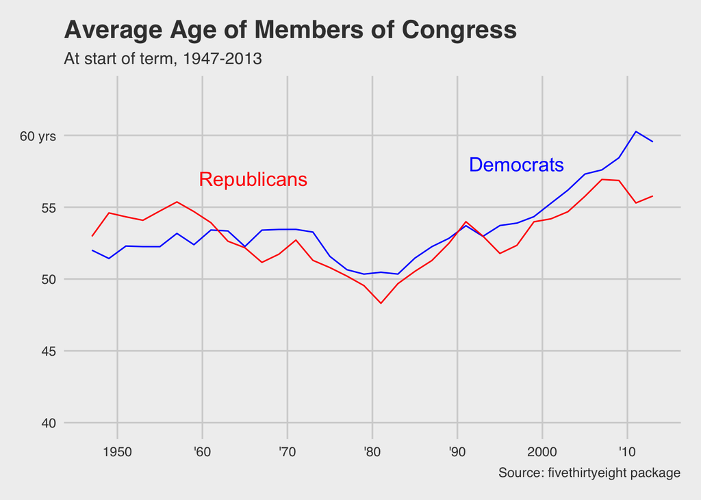